# Cointegration in Crude Prices

Cameron Pfiffer

July 17, 2017

# Introduction

Determining whether global oil markets are cointegrated is an important question, as doing so would allow a market participant to formulate trading strategies in cases where short-term relationships break down. It makes economic sense for the two oil grades to be cointegrated – they are essentially substitutes, with similar specific gravities and sulfur content. Indeed, Adelman (1984) claimed that “The world oil market, like the world ocean, is one great pool.” This study reviews existing literature, examines the statistical relationship between Brent crude and West Texas Intermediate (WTI) crude, and proposes a trading strategy based on cointegration between the two securities.

# Literature Review

## Cointegration

Cointegration as a concept was first introduced by Granger (1981), and later expanded upon to include methodology for testing cointegration (Engle and Granger, 1987). The theory states that non-stationary series integrated of the same order may have a cointegrating vector that reduces the resulting series to a stationary process, in which case the series are said to be *cointegrated*. Assets linked by a fundamental relationship have cause to be cointegrated, and the crude oil markets are no exception. WTI and Brent crudes are both highly similar commodities, with proximate specific gravities and sulfur contents. It makes sense that two nearly fungible assets would trade at similar levels, ignoring cost of carry and transit costs. Johansen (1991) later expanded upon the Engle-Granger methodology to expand to multivariate cointegrating relationships, and offered a solution to the issue of declaring one variable dependent on the other. This paper uses both methodologies to test for cointegration.

There are consistent findings amongst academics that WTI and Brent are cointegrated, and that oil levels are $I(1)$, but stationary in first differences, consistent with expectations. Hammoudeh et al. (2008) found cointegrating relationships in Brent and WTI (as well as Dubai and Maya crudes) using both the Engle-Granger method (1987) and the M-TAR approach (Enders and Granger, 1998; Enders and Siklos, 2001) which permits asymmetry in the return to equilibrium levels[^1]. Fattouh (2010) finds similar cointegrating relationships, though notes the presence of structural breaks and non-stationarity in crude price differentials in some extraordinary time periods. Numerous other academics have confirmed the existence of cointegration (Azar and Salha, 2017; Gülen, 1997; Kim et al., 2009; Reboredo, 2011) using a variety of methodologies.

## Trading Strategy and Transaction Costs

Developing a trading strategy to requires the awareness of several key facts. First, in a world absent transaction costs, any deviation from the mean should spur immediate mean reversion no matter how small, as noted by Balke and Famby (1997). However, as we do not live in a world absent transaction costs and this is an empirical study (and thus subject to the whims of reality), an appropriate transaction cost must be assumed to evaluate the profitability of any trade. In this study, transaction costs are included by construction, as the trading simulation assumes that all purchases are make on the ask and all sales made on the bid. This is an overly simplified assumption, as this merely accounts for explicit transaction costs, and not implicit costs such as opportunity cost and market impact, among others[^2].

Kawasaki et al. (2003) study contrarian and momentum trading strategies in cointegrated equities. Given that integrated series cross the mean frequently, the authors note that there are two general outcomes; first, that the spread between assets might continue away from the mean due to momentum; second, that an asset will revert towards the mean. They find Sharpe ratios of approximately 0.90 for the momentum strategy, and 0.59 for the contrarian strategy, though it should be noted that the contrarian strategy had far higher average returns, 10.69% versus the momentum strategy’s 6.46%.

# Data

# Lag Length Selection

It has been noted that lag length selection can have important effects on a VAR model’s impulse response and variance decompositions (Braun and Mittnik, 1993), and Brooks (2014) notes that Johansen tests and Augmented Dickey-Fuller tests can be sucestible to improper lag selection. Thus, we select a lag length that creates produces the most parsimonious model, i.e., the smallest lag length. The `vars` package for R (Pfaff et al., 2013) contains a built in function for multivariate information criterion,

$$SC(n) = \ln \det(\tilde{Σ}_u(n)) + \frac{\ln(T)}{T}n K^2 \quad$$

|  | Lag Length |
| --- | --- |
| AIC(n) | 9 |
| HQ(n) | 3 |
| SC(n) | 2 |
| FPE(n) | 9 |

# Stationarity

# Testing for cointegration

This test evaluates whether or not an intercept would help model the data better.

```r
joc <- ca.jo(price, type = 'eigen', ecdet = 'const',
                  K = 2, spec = 'transitory')
summary(joc)
```

```
##
## ######################
## # Johansen-Procedure #
## ######################
##
## Test type: maximal eigenvalue statistic (lambda max) , without linear trend and constant in cointegration
##
## Eigenvalues (lambda):
## [1] 4.959246e-03 4.493893e-04 3.030525e-20
##
## Values of teststatistic and critical values of test:
##
##           test 10pct  5pct  1pct
## r <= 1 |  2.50  7.52  9.24 12.97
## r = 0  | 27.69 13.75 15.67 20.20
##
## Eigenvectors, normalised to first column:
## (These are the cointegration relations)
##
##              wti.l1   brent.l1   constant
## wti.l1    1.0000000   1.000000    1.00000
## brent.l1 -0.8744584  -8.967269   12.76651
## constant -5.3145220 497.320087 1278.16529
##
## Weights W:
## (This is the loading matrix)
##
##                wti.l1     brent.l1      constant
## wti.d   -0.0124957220 7.615225e-05  3.687967e-20
## brent.d -0.0006735095 9.398675e-05 -5.887519e-21
```

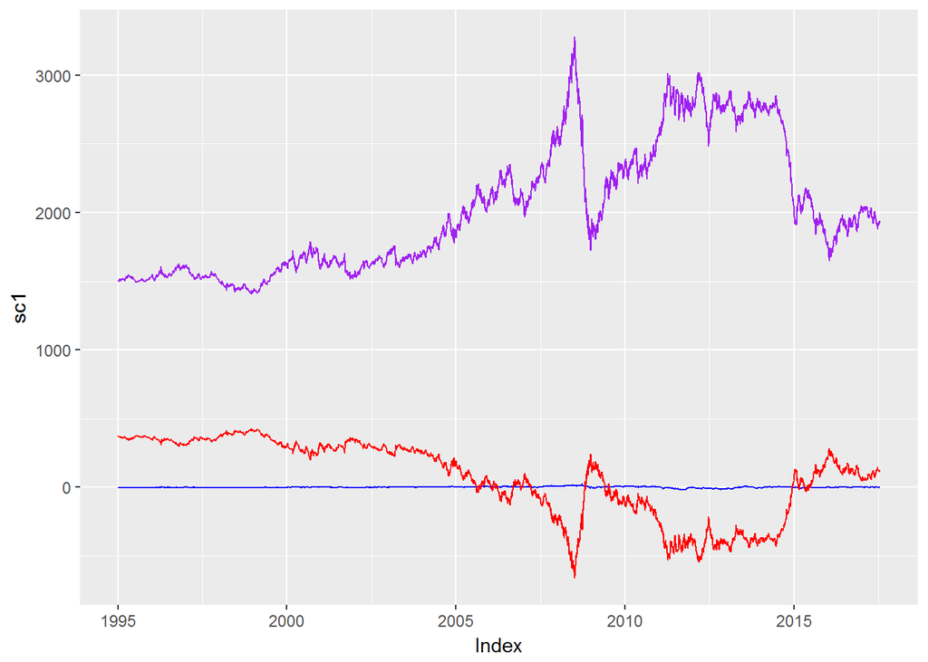

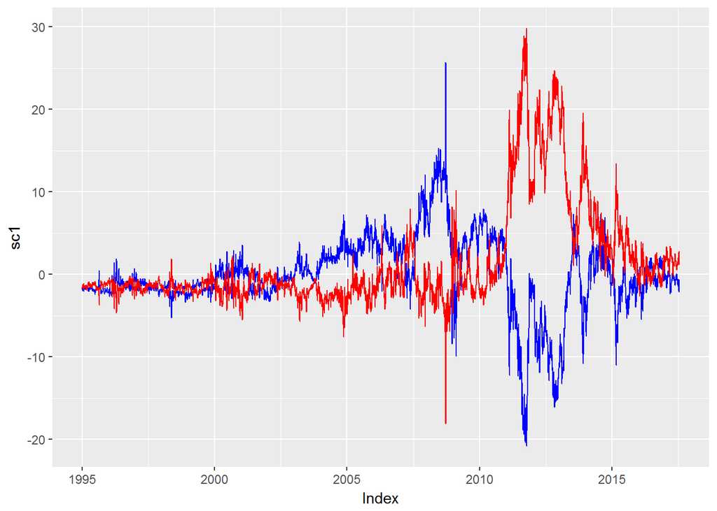

# Turning the VECM into a VAR

# References

Adelman, M.A., 1984. International oil agreements. The Energy Journal 5, 1–9.

Almgren, R., Chriss, N., 2001. Optimal execution of portfolio transactions. Journal of Risk 3, 5–40.

Azar, S.A., Salha, A., 2017. The bias in the long run relation between the prices of brent and wti crude oils. International Journal of Energy Economics and Policy 7.

Balke, N.S., Fomby, T.B., 1997. Threshold cointegration. International Economic Review 38, 627–645.

Braun, P., Mittnik, S., 1993. Misspecifications in vector autoregressions and their effects on impulse responses and variance decompositions. Journal of Econometrics 59, 319–341. doi:10.1016/0304-4076(93)90029-5

Brooks, C., 2014. Introductory econometrics for finance. Cambridge university press.

Enders, W., Granger, C.W.J., 1998. Unit-root tests and asymmetric adjustment with an example using the term structure of interest rates. Journal of Business & Economic Statistics 16, 304–311. doi:10.1080/07350015.1998.10524769

Enders, W., Siklos, P., 2001. Cointegration and threshold adjustment. Journal of Business & Economic Statistics 19, 166–76.

Engle, R.F., Granger, C.W., 1987. Co-integration and error correction: Representation, estimation, and testing. Econometrica: journal of the Econometric Society 251–276.

Fattouh, B., 2010. The dynamics of crude oil price differentials. Energy Economics 32, 334–342. doi:http://dx.doi.org/10.1016/j.eneco.2009.06.007

Granger, C.W., 1981. Some properties of time series data and their use in econometric model specification. Journal of econometrics 16, 121–130.

Gülen, S.G., 1997. Regionalization in the world crude oil market. The Energy Journal 18, 109–126.

Hammoudeh, S.M., Ewing, B.T., Thompson, M.A., 2008. Threshold cointegration analysis of crude oil benchmarks. The Energy Journal 29, 79–95.

Johansen, S., 1991. Estimation and hypothesis testing of cointegration vectors in gaussian vector autoregressive models. Econometrica 59, 1551–1580.

Kawasaki, Y., Tachiki, S., Udaka, H., Hirano, T., 2003. A characterization of long-short trading strategies based on cointegration, in: Computational Intelligence for Financial Engineering, 2003. Proceedings. 2003 Ieee International Conference on. IEEE, pp. 411–416.

Kim, J., Oh, S., Heo, E., 2009. A study on integration of the world crude oil markets using price asymmetry model. Geosystem Engineering 12, 1–4.

Kissell, R., 2006. The expanded implementation shortfall: Understanding transaction cost components. The Journal of Trading 1, 6–16.

Pfaff, B., Stigler, M., Pfaff, M.B., 2013. Package “vars”.

Reboredo, J.C., 2011. How do crude oil prices co-move? Energy Economics 33, 948–955. doi:http://dx.doi.org/10.1016/j.eneco.2011.04.006

[^1]: Hammoudeh (2008) notes that there is cause to suspect asymmetrical returns to equilibrium; he cites the heterogeneity in global trader’s expectations, compulsive and noisy trading, and transaction costs as potential factors. Asymmetry is highly important for trading strategies, though for simplicity, the cointegrating relationship between Brent and WTI is assumed to be symmetric.
[^2]: See Almgren and Chriss (2001) and Kissel (2006) for expanded transaction cost analysis methods.